# Homework 1

Shannon Hamilton

2/4/2018

My Github repository for my assignments can be found at this URL: https://github.com/shannonleehamilton/compscix-415-2-assignments

```r
library(mdsr)

library(tidyverse)

data("WorldCities")
```

QUESTION 1: How many observations and variables are there in this data set? What are some of the variable names?

There are 10 variables in the data set, incuding latitude, longitude, country and population. Therea are 23,018 observations.

```r
country_col <- WorldCities$country
unique(country_col)
```

```
##   [1] "AD" "AE" "AF" "AG" "AI" "AL" "AM" "AO" "AR" "AS" "AT" "AU" "AW" "AX"
##  [15] "AZ" "BA" "BB" "BD" "BE" "BF" "BG" "BH" "BI" "BJ" "BL" "BM" "BN" "BO"
##  [29] "BQ" "BR" "BS" "BT" "BW" "BY" "BZ" "CA" "CC" "CD" "CF" "CG" "CH" "CI"
##  [43] "CK" "CL" "CM" "CN" "CO" "CR" "CU" "CV" "CW" "CX" "CY" "CZ" "DE" "DJ"
##  [57] "DK" "DM" "DO" "DZ" "EC" "EE" "EG" "EH" "ER" "ES" "ET" "FI" "FJ" "FK"
##  [71] "FM" "FO" "FR" "GA" "GB" "GD" "GE" "GF" "GG" "GH" "GI" "GL" "GM" "GN"
##  [85] "GP" "GQ" "GR" "GS" "GT" "GU" "GW" "GY" "HK" "HN" "HR" "HT" "HU" "ID"
##  [99] "IE" "IL" "IM" "IN" "IQ" "IR" "IS" "IT" "JE" "JM" "JO" "JP" "KE" "KG"
## [113] "KH" "KI" "KM" "KN" "KP" "KR" "KW" "KY" "KZ" "LA" "LB" "LC" "LI" "LK"
## [127] "LR" "LS" "LT" "LU" "LV" "LY" "MA" "MC" "MD" "ME" "MF" "MG" "MH" "MK"
## [141] "ML" "MM" "MN" "MO" "MP" "MQ" "MR" "MS" "MT" "MU" "MV" "MW" "MX" "MY"
## [155] "MZ" NA   "NC" "NE" "NF" "NG" "NI" "NL" "NO" "NP" "NU" "NZ" "OM" "PA"
## [169] "PE" "PF" "PG" "PH" "PK" "PL" "PM" "PN" "PR" "PS" "PT" "PW" "PY" "QA"
## [183] "RE" "RO" "RS" "RU" "RW" "SA" "SB" "SC" "SD" "SE" "SG" "SH" "SI" "SJ"
## [197] "SK" "SL" "SM" "SN" "SO" "SR" "SS" "ST" "SV" "SX" "SY" "SZ" "TC" "TD"
## [211] "TF" "TG" "TH" "TJ" "TL" "TM" "TN" "TO" "TR" "TT" "TV" "TW" "TZ" "UA"
## [225] "UG" "US" "UY" "UZ" "VA" "VC" "VE" "VG" "VI" "VN" "VU" "WF" "WS" "XK"
## [239] "YE" "YT" "ZA" "ZM" "ZW"
```

```r
glimpse(WorldCities)
```

```
## Observations: 23,018
## Variables: 10
## $ code          <int> 3040051, 3041563, 290594, 291074, 291696, 292223...
## $ name          <chr> "les Escaldes", "Andorra la Vella", "Umm al Qayw...
## $ latitude      <dbl> 42.50729, 42.50779, 25.56473, 25.78953, 25.33132...
## $ longitude     <dbl> 1.53414, 1.52109, 55.55517, 55.94320, 56.34199, ...
## $ country       <chr> "AD", "AD", "AE", "AE", "AE", "AE", "AE", "AE", ...
## $ countryRegion <chr> "8", "7", "7", "5", "6", "3", "4", "6", "1", "4"...
## $ population    <dbl> 15853, 20430, 44411, 115949, 33575, 1137347, 263...
## $ regionCode    <int> 1033, 1037, 2, 2, 20, 11, 4, 6, 16, 15, 275, 4, ...
## $ region        <chr> "Europe/Andorra", "Europe/Andorra", "Asia/Dubai"...
## $ date          <chr> "10/15/08", "5/30/10", "11/3/12", "11/30/12", "1...
```

```r
summary(WorldCities)
```

```
##       code             name              latitude        longitude
##  Min.   :  14256   Length:23018       Min.   :-54.80   Min.   :-176.17
##  1st Qu.:1266056   Class :character   1st Qu.: 14.99   1st Qu.: -42.86
##  Median :2478221   Mode  :character   Median : 34.46   Median :  15.57
##  Mean   :2535911                      Mean   : 27.89   Mean   :  16.17
##  3rd Qu.:3458556                      3rd Qu.: 44.78   3rd Qu.:  75.06
##  Max.   :8605041                      Max.   : 78.22   Max.   : 179.38
##    country          countryRegion        population
##  Length:23018       Length:23018       Min.   :       0
##  Class :character   Class :character   1st Qu.:   21998
##  Mode  :character   Mode  :character   Median :   35792
##                                        Mean   :  112625
##                                        3rd Qu.:   75531
##                                        Max.   :14608512
##    regionCode         region              date
##  Min.   :-9999.0   Length:23018       Length:23018
##  1st Qu.:   31.0   Class :character   Class :character
##  Median :  128.0   Mode  :character   Mode  :character
##  Mean   :  286.8
##  3rd Qu.:  342.0
##  Max.   : 5022.0
```

```r
WorldCities <- head(WorldCities, 200)
unique(country_col)
```

```
##   [1] "AD" "AE" "AF" "AG" "AI" "AL" "AM" "AO" "AR" "AS" "AT" "AU" "AW" "AX"
##  [15] "AZ" "BA" "BB" "BD" "BE" "BF" "BG" "BH" "BI" "BJ" "BL" "BM" "BN" "BO"
##  [29] "BQ" "BR" "BS" "BT" "BW" "BY" "BZ" "CA" "CC" "CD" "CF" "CG" "CH" "CI"
##  [43] "CK" "CL" "CM" "CN" "CO" "CR" "CU" "CV" "CW" "CX" "CY" "CZ" "DE" "DJ"
##  [57] "DK" "DM" "DO" "DZ" "EC" "EE" "EG" "EH" "ER" "ES" "ET" "FI" "FJ" "FK"
##  [71] "FM" "FO" "FR" "GA" "GB" "GD" "GE" "GF" "GG" "GH" "GI" "GL" "GM" "GN"
##  [85] "GP" "GQ" "GR" "GS" "GT" "GU" "GW" "GY" "HK" "HN" "HR" "HT" "HU" "ID"
##  [99] "IE" "IL" "IM" "IN" "IQ" "IR" "IS" "IT" "JE" "JM" "JO" "JP" "KE" "KG"
## [113] "KH" "KI" "KM" "KN" "KP" "KR" "KW" "KY" "KZ" "LA" "LB" "LC" "LI" "LK"
## [127] "LR" "LS" "LT" "LU" "LV" "LY" "MA" "MC" "MD" "ME" "MF" "MG" "MH" "MK"
## [141] "ML" "MM" "MN" "MO" "MP" "MQ" "MR" "MS" "MT" "MU" "MV" "MW" "MX" "MY"
## [155] "MZ" NA   "NC" "NE" "NF" "NG" "NI" "NL" "NO" "NP" "NU" "NZ" "OM" "PA"
## [169] "PE" "PF" "PG" "PH" "PK" "PL" "PM" "PN" "PR" "PS" "PT" "PW" "PY" "QA"
## [183] "RE" "RO" "RS" "RU" "RW" "SA" "SB" "SC" "SD" "SE" "SG" "SH" "SI" "SJ"
## [197] "SK" "SL" "SM" "SN" "SO" "SR" "SS" "ST" "SV" "SX" "SY" "SZ" "TC" "TD"
## [211] "TF" "TG" "TH" "TJ" "TL" "TM" "TN" "TO" "TR" "TT" "TV" "TW" "TZ" "UA"
## [225] "UG" "US" "UY" "UZ" "VA" "VC" "VE" "VG" "VI" "VN" "VU" "WF" "WS" "XK"
## [239] "YE" "YT" "ZA" "ZM" "ZW"
```

QUESTION 2: There is a column called region in the data set. Can you extract this and show only the unique values?

[1] “Europe/Andorra” “Asia/Dubai”  
[3] “Asia/Kabul” “America/Antigua”  
[5] “America/Anguilla” “Europe/Tirane”  
[7] “Asia/Yerevan” “Africa/Luanda”  
[9] “America/Argentina/Buenos_Aires” “America/Argentina/Cordoba”  
[11] “America/Argentina/Salta” “America/Argentina/Tucuman”  
[13] “America/Argentina/San_Juan”

```r
country_col <- WorldCities$country
region_col <- WorldCities$region
unique(region_col)
```

```
##  [1] "Europe/Andorra"                 "Asia/Dubai"
##  [3] "Asia/Kabul"                     "America/Antigua"
##  [5] "America/Anguilla"               "Europe/Tirane"
##  [7] "Asia/Yerevan"                   "Africa/Luanda"
##  [9] "America/Argentina/Buenos_Aires" "America/Argentina/Cordoba"
## [11] "America/Argentina/Salta"        "America/Argentina/Tucuman"
## [13] "America/Argentina/San_Juan"
```

QUESTION 3: Can you extract and show the unique entries from the country column in WorldCities using one line of code and two %>% operators?

```r
WorldCities %>% select(country) %>% unique()
```

```
##     country
## 1        AD
## 3        AE
## 15       AF
## 65       AG
## 66       AI
## 67       AL
## 87       AM
## 104      AO
## 131      AR
```

[output not shown]

QUESTION 4: Make one more histogram of the population and add a new x-label, a new ylabel, a new title (use ggtitle(‘my title’)), and change the theme of the plot using theme_bw().

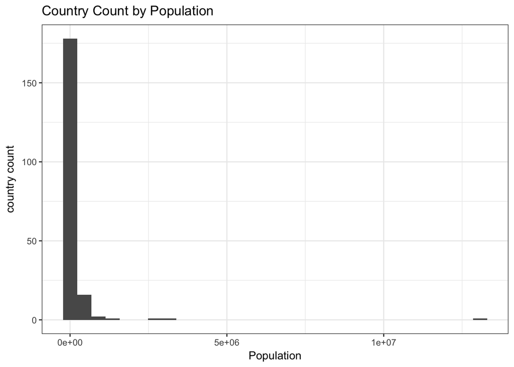

```r
PopPlot <- WorldCities %>% ggplot(aes(x = population)) +
geom_histogram()

print(PopPlot + labs (title="Country Count by Population", y="country count", x="Population") + theme_bw())
```